# FinalProjRmarkDown

Ian Aksland

12/7/2019

# Introduction

I work on instrumentation for enviornmental measurment, and how we can use this data in a meaningful way.

The system we used this last summer uses our openIoTsensor boards, and a variety of soil moisture sensors.

They were installed at City Park Nine Golf Course fairway-7. We installed all 7 moisture sensors within close proximity.

We used 2 dollars for DFrobot, 22 dollars for SoilWatch10, 25 dollars for Tinovi, and 135 dollars for EC5 sensors.

# Data Processing

## Dark Sky Data Collection

**You must type in your Dark Sky Secret Key in console before proceeding**

API request from Dark Sky

```r
darksky_api_key() # Set Secret Key
```

Input of Desired Lat,Long Cordinates

```r
latitude <- 40.582753
longitude <- -105.112879
```

Get daily and predicted forcast for following week, and display today weather.

```r
now <- get_current_forecast(latitude, longitude, units = "us", language = "en",
exclude = 'hourly,currently,minutely', extend = "daily", add_json = FALSE, add_headers = TRUE)
```

### Ugly Table

```r
now_daily <-  now$daily %>%
  select(-precipType)
print(head(now$daily,1))
```

```
##         time                           summary              icon
## 1 2019-12-11 Partly cloudy throughout the day. partly-cloudy-day
##           sunriseTime          sunsetTime moonPhase precipIntensity
## 1 2019-12-11 07:15:00 2019-12-11 16:35:00       0.5           6e-04
##   precipIntensityMax precipIntensityMaxTime precipProbability precipType
## 1             0.0022    2019-12-11 14:16:00              0.14       snow
##   precipAccumulation temperatureHigh temperatureHighTime temperatureLow
## 1               0.07           40.94          1576097760          24.29
##   temperatureLowTime apparentTemperatureHigh apparentTemperatureHighTime
## 1         1576158840                   40.57                  1576099920
##   apparentTemperatureLow apparentTemperatureLowTime dewPoint humidity
## 1                  20.38                 1576157460    20.93     0.67
##   pressure windSpeed windGust windGustTime windBearing cloudCover uvIndex
## 1   1019.7       3.7     11.2   1576133460         304       0.43       2
##   uvIndexTime visibility ozone temperatureMin  temperatureMinTime
## 1  1576089780         10 314.8          21.18 2019-12-11 06:52:00
##   temperatureMax  temperatureMaxTime apparentTemperatureMin
## 1          40.94 2019-12-11 13:56:00                  16.23
##   apparentTemperatureMinTime apparentTemperatureMax
## 1        2019-12-11 04:55:00                  40.57
##   apparentTemperatureMaxTime
## 1        2019-12-11 14:32:00
```

```r
now_only <- head(now$daily,1)
```

### Cool Table

```r
now_only <- gather(now_only,key = "Data Type",Value)
kable(now_only) %>%
  kable_styling(latex_options = "striped")
```

| Data Type | Value |
| --- | --- |
| time | 1576047600 |
| summary | Partly cloudy throughout the day. |
| icon | partly-cloudy-day |
| sunriseTime | 1576073700 |
| sunsetTime | 1576107300 |
| moonPhase | 0.5 |
| precipIntensity | 6e-04 |
| precipIntensityMax | 0.0022 |
| precipIntensityMaxTime | 1576098960 |
| precipProbability | 0.14 |
| precipType | snow |
| precipAccumulation | 0.07 |
| temperatureHigh | 40.94 |
| temperatureHighTime | 1576097760 |
| temperatureLow | 24.29 |
| temperatureLowTime | 1576158840 |
| apparentTemperatureHigh | 40.57 |
| apparentTemperatureHighTime | 1576099920 |
| apparentTemperatureLow | 20.38 |
| apparentTemperatureLowTime | 1576157460 |
| dewPoint | 20.93 |
| humidity | 0.67 |
| pressure | 1019.7 |
| windSpeed | 3.7 |
| windGust | 11.2 |
| windGustTime | 1576133460 |
| windBearing | 304 |
| cloudCover | 0.43 |
| uvIndex | 2 |
| uvIndexTime | 1576089780 |
| visibility | 10 |
| ozone | 314.8 |
| temperatureMin | 21.18 |
| temperatureMinTime | 1576072320 |
| temperatureMax | 40.94 |
| temperatureMaxTime | 1576097760 |
| apparentTemperatureMin | 16.23 |
| apparentTemperatureMinTime | 1576065300 |
| apparentTemperatureMax | 40.57 |
| apparentTemperatureMaxTime | 1576099920 |

### Hourly Weather Data for a Specific Day

Takes hourly weather data from 7/30/2019. If I messed with the time stamp I think I could get it to work right, but a quicker fix was just putting in the 31st to get it to work.

```r
timestamp <- as.Date("2019-07-31")  # starting day you want but you must do the following day for it to work I want the 30th so I did 31
timestampWithTime <- paste(timestamp,"T00:00:00",sep="") # add time to the date to match darksky api
forecast <- get_forecast_for(latitude, longitude, timestamp, units = "us",
language = "en", exclude = 'currently,minutely,daily', add_json = FALSE,
add_headers = FALSE)
if(ncol(forecast$hourly)==18){
dataWeatherForeCastHour <- forecast$hourly %>%
  select(-precipType)
}else {
  dataWeatherForeCastHour <- forecast$hourly
}
combinedWeatherData <- dataWeatherForeCastHour
```

### Hourly Weather Data for Range of Days(One Table)

Now I’ll get the real weather data I need from 7/30/2019 to 8/27/2019

**ISSUE:** When we have no rain event the precipType column goes away so I had to add an IF statment to check for that.

I also had to format the date by year-month-day to match API

I rbind every new day to the previous set. I print each day to make sure, and easily get a combined weatherdata over my time range.

```r
dates <- seq(from = as.Date("2019-07-31"), to = as.Date("2019-08-27"), by=1)
for (i in as.list(dates))
{
  print(i)
timestampNew <- paste(i,"T00:00:00",sep="")
forecastNew <- get_forecast_for(latitude, longitude, timestampNew, units = "us",
language = "en", exclude = 'currently,minutely,daily', add_json = FALSE,
add_headers = FALSE)
if(ncol(forecastNew$hourly)==18){
dataWeatherForeCastHourNew <- forecastNew$hourly %>%
  select(-precipType)
}
else{
  dataWeatherForeCastHourNew <- forecastNew$hourly
}
combinedWeatherData <- rbind(combinedWeatherData,dataWeatherForeCastHourNew)
}
```

```
## [1] "2019-07-31"
## [1] "2019-08-01"
## [1] "2019-08-02"
## [1] "2019-08-03"
## [1] "2019-08-04"
## [1] "2019-08-05"
## [1] "2019-08-06"
## [1] "2019-08-07"
## [1] "2019-08-08"
## [1] "2019-08-09"
## [1] "2019-08-10"
## [1] "2019-08-11"
## [1] "2019-08-12"
## [1] "2019-08-13"
## [1] "2019-08-14"
## [1] "2019-08-15"
## [1] "2019-08-16"
## [1] "2019-08-17"
## [1] "2019-08-18"
## [1] "2019-08-19"
## [1] "2019-08-20"
## [1] "2019-08-21"
## [1] "2019-08-22"
## [1] "2019-08-23"
## [1] "2019-08-24"
## [1] "2019-08-25"
## [1] "2019-08-26"
## [1] "2019-08-27"
```

## Sensor Data Collection

### Bring Data in from csv Files Generated by Ubidots

We had four different soil moisture sensors and soil temperature in Celsius.

```r
dfRobot <- read.csv("C:/Users/ianak/Documents/WR674/FinalProjectNew/WR674-Final-Project/data/widget_data_df-robot-clone.csv")

soilWatch10 <- read.csv("C:/Users/ianak/Documents/WR674/FinalProjectNew/WR674-Final-Project/data/widget_data_soilwatch-10.csv")

EC5 <- read.csv("C:/Users/ianak/Documents/WR674/FinalProjectNew/WR674-Final-Project/data/widget_data_ec-5.csv")

tinovi <- read.csv("C:/Users/ianak/Documents/WR674/FinalProjectNew/WR674-Final-Project/data/widget_data_tinovi-vwc.csv")

soilTemp <- read.csv("C:/Users/ianak/Documents/WR674/FinalProjectNew/WR674-Final-Project/data/widget_data_soil-temp-c.csv")
```

### DF Robot Sensor Combine with Weather Data

**ISSUE:** I had to g-sub the seconds column to be zeros to match weather data times, and change the date format.

It was a few seconds off from the hour becasue the cellular antenna/connection takes some time to connect and send data to the cloud.

It won’t take more than a minute b/c the system was coded to only try for 30 seconds, so I only replace the seconds with “00”.

I also did some column removal, renamed unfreindly column names, and got rid of N/A values generated from missing sensors values casued by a weak cellular conection.

An improvment would be to not hardcode names; instead grab the name based on column number so it works for any name.

```r
for(r in dfRobot){
dfRobot$time <- gsub(":.{2}$",":00",dfRobot$Human.readable.date) %>%
  as.POSIXct()
}


df_weather_combine <- left_join(combinedWeatherData,dfRobot, by = "time")
df_weather_remv_na <- na.omit(df_weather_combine) %>%
  select(-Timestamp,-context_e00fce6872359b9131374b7c_dfrobot.sm3.calibrated,-context_e00fce6872359b9131374b7c_dfrobot.sm6.calibrated,-icon, -ozone) %>%
  rename(dfRobotSensor_3 = e00fce6872359b9131374b7c_dfrobot.sm3.calibrated, dfRobotSensor_6 = e00fce6872359b9131374b7c_dfrobot.sm6.calibrated,rawTime = Human.readable.date)
```

### Soil Watch-10 Sensor Combine with DFrobot and Weather Data

Same data adjustments and the DF robot sensor

```r
for(r in soilWatch10){
soilWatch10$time <- gsub(":.{2}$",":00",soilWatch10$Human.readable.date) %>%
  as.POSIXct()
}

sw_df_weather_remv_na <- left_join(df_weather_remv_na,soilWatch10, by = "time") %>%
  na.omit(sw_df_weather_remv_na) %>%
  select(-Timestamp,-context_e00fce6872359b9131374b7c_sw.10.sensor.2.calibrated,-context_e00fce6872359b9131374b7c_sw.10.sm5.calibrated,-Human.readable.date) %>%
  rename(soilWatchSensor_2 = e00fce6872359b9131374b7c_sw.10.sensor.2.calibrated, soilWatchSensor_5 = e00fce6872359b9131374b7c_sw.10.sm5.calibrated)
```

### EC-5 Sensor Combine with DFrobot, SoilWatch10, and Weather Data

Same data adjustments as the others

```r
for(r in EC5){
EC5$time <- gsub(":.{2}$",":00",EC5$Human.readable.date) %>%
  as.POSIXct()
}

EC_sw_df_weather_remv_na <- left_join(sw_df_weather_remv_na,EC5, by = "time") %>%
  na.omit(sw_df_weather_remv_na) %>%
  select(-Timestamp,-context_e00fce6872359b9131374b7c_ec.5.calibrated,-context_e00fce6872359b9131374b7c_ec.5.sm4.calibrated,-Human.readable.date) %>%
  rename(EC5_1 = e00fce6872359b9131374b7c_ec.5.calibrated, EC5_4 = e00fce6872359b9131374b7c_ec.5.sm4.calibrated)
```

### Tinovi Sensor Combine with DFrobot, SoilWatch10, EC5, and Weather Data

Same data adjustments as the others

```r
for(r in tinovi){
tinovi$time <- gsub(":.{2}$",":00",tinovi$Human.readable.date) %>%
  as.POSIXct()
}

tin_EC_sw_df_weather_remv_na <- left_join(EC_sw_df_weather_remv_na,tinovi, by = "time") %>%
  na.omit(sw_df_weather_remv_na) %>%
  select(-Timestamp,-context_e00fce6872359b9131374b7c_tinovi.calibrated,-Human.readable.date) %>%
  rename(tinovi_7 = e00fce6872359b9131374b7c_tinovi.calibrated)
```

### Soil Temp Sensor Combine with DFrobot, SoilWatch10, EC5, and Weather Data

Same data adjustments as the others **AND** with a distinct(time) to eliminate any duplicate readings.

We now have a final dataset we can use with hourly weather data from 7/30/2019 to 8/27/2019 with seven corresponding soil moisture readings and temperature data!

```r
for(r in tinovi){
soilTemp$time <- gsub(":.{2}$",":00",soilTemp$Human.readable.date) %>%
  as.POSIXct()
}

st_tin_EC_sw_df_weather_remv_na_dups <- left_join(tin_EC_sw_df_weather_remv_na,soilTemp, by = "time") %>%
  na.omit(st_tin_EC_sw_df_weather_remv_na_dups) %>%
  select(-Timestamp,-context_e00fce6872359b9131374b7c_soiltemp,-Human.readable.date) %>%
  rename(soilTempC = e00fce6872359b9131374b7c_soiltemp)%>%
  distinct(time,.keep_all = TRUE)

finalDataSet_long <- st_tin_EC_sw_df_weather_remv_na_dups
```

# Plots and Visuals

## Information on Data Collection Strategies

On Aug 7th we flashed new code with a smoothing function that took 900 hundred readings per sensor and then took the avg of the middle 300 values.

All sensors were installed at one inch depth all within in a foot of eachother. Location on the rough of the golf course.

We also noticed that some sensors were more sensitive to temperature effecting readings(Shown in a graph below).

Jim, the golf course superintendent allowed us to have full control of the irrigation in the area.

We had two major irrigation differences, until about Aug 19th we went from fully-saturation to fully field dry. After that we had constant irrigation events every day.

## Showing Off the Data

### Basic Graph

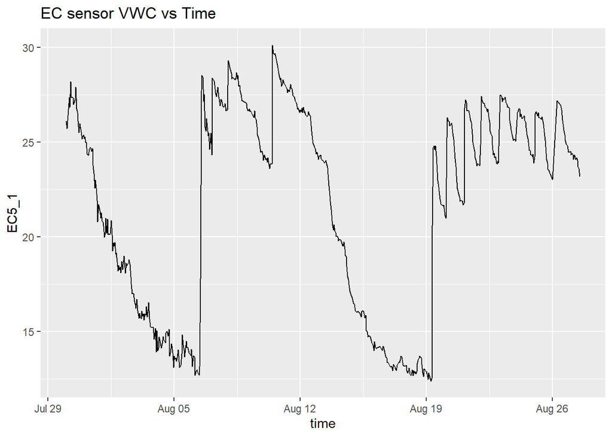

```r
qplot(x = time,y = EC5_1,data = finalDataSet_long, main = "EC sensor VWC vs Time",
                                            geom = "line")
```

### Better Graphs

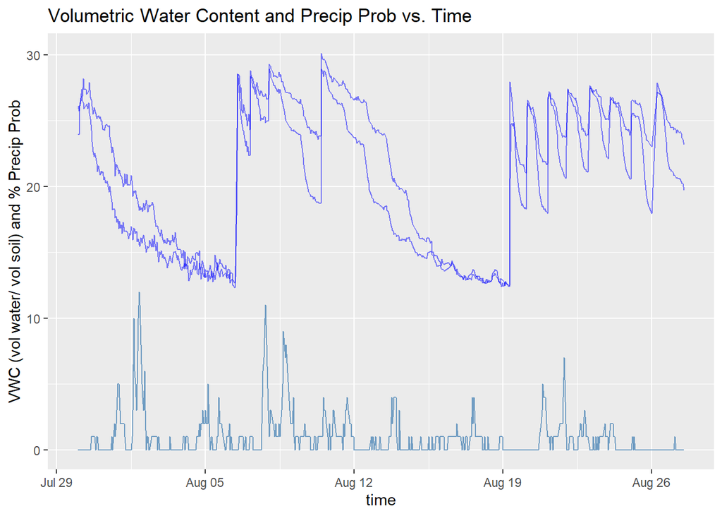

```r
plot = ggplot() +
geom_line(data = finalDataSet_long, aes(x = time, y = EC5_1), color = "blue", alpha=0.5) +
  geom_line(data = finalDataSet_long, aes(x = time, y = EC5_4), color = "blue",alpha=0.5) +
  geom_line(data = finalDataSet_long, aes(x = time, y = precipProbability*100), color = "steelblue", alpha=0.75) +
    ylab("VWC (vol water/ vol soil) and % Precip Prob")+
    ggtitle("Volumetric Water Content and Precip Prob vs. Time") # for the main title

plot
```

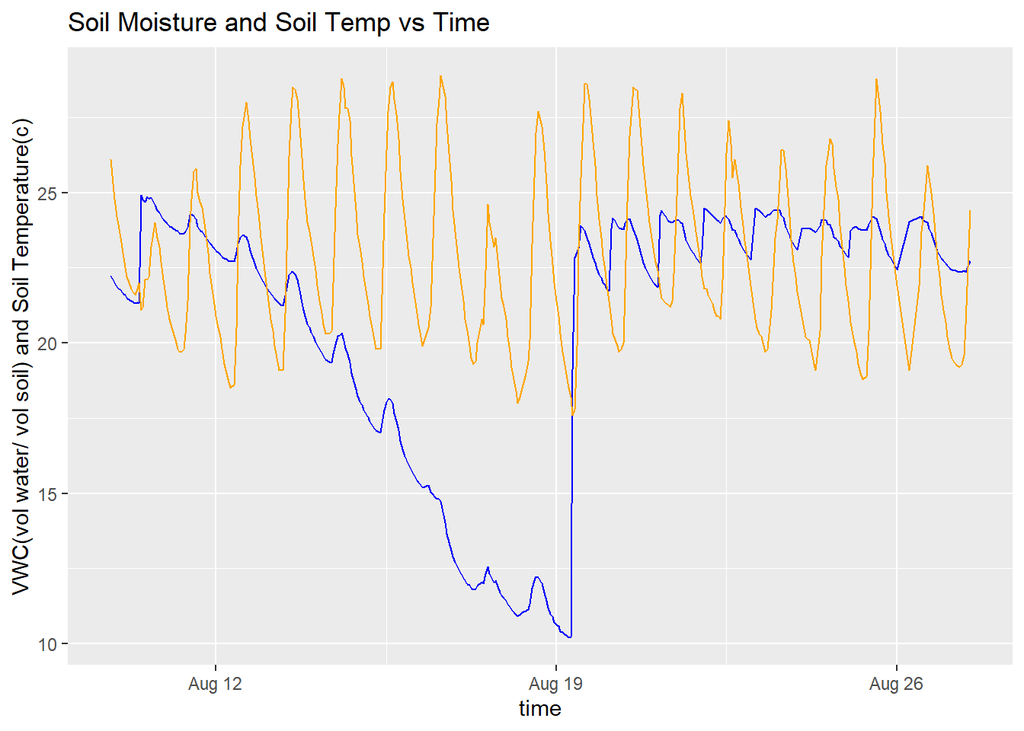

```r
plot2 = ggplot() +
geom_line(data = tail(finalDataSet_long,-240), aes(x = time, y = soilWatchSensor_2), color = "blue") +
  geom_line(data = tail(finalDataSet_long,-240), aes(x = time, y = soilTempC), color = "orange")+
  ylab("VWC(vol water/ vol soil) and Soil Temperature(c)")+
  ggtitle("Soil Moisture and Soil Temp vs Time")

plot2
```

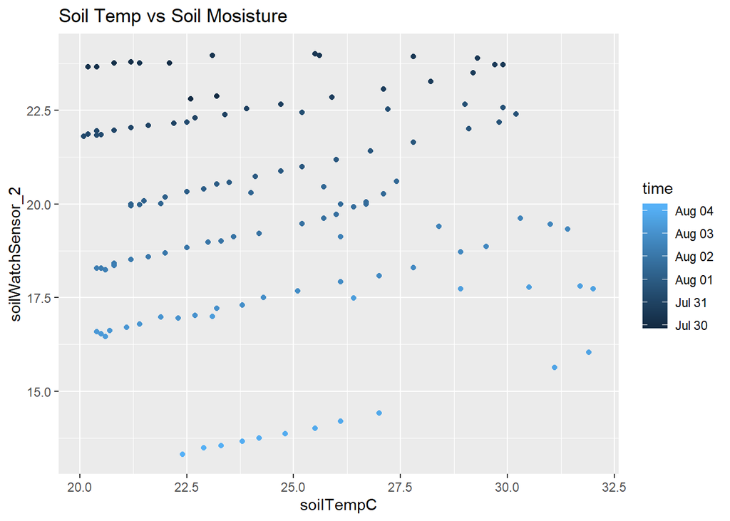

```r
ggplot(data=finalDataSet_long[1:120,],aes(y=soilWatchSensor_2,x=soilTempC,color=time)) +
  geom_point()+
  ggtitle("Soil Temp vs Soil Mosisture")
```

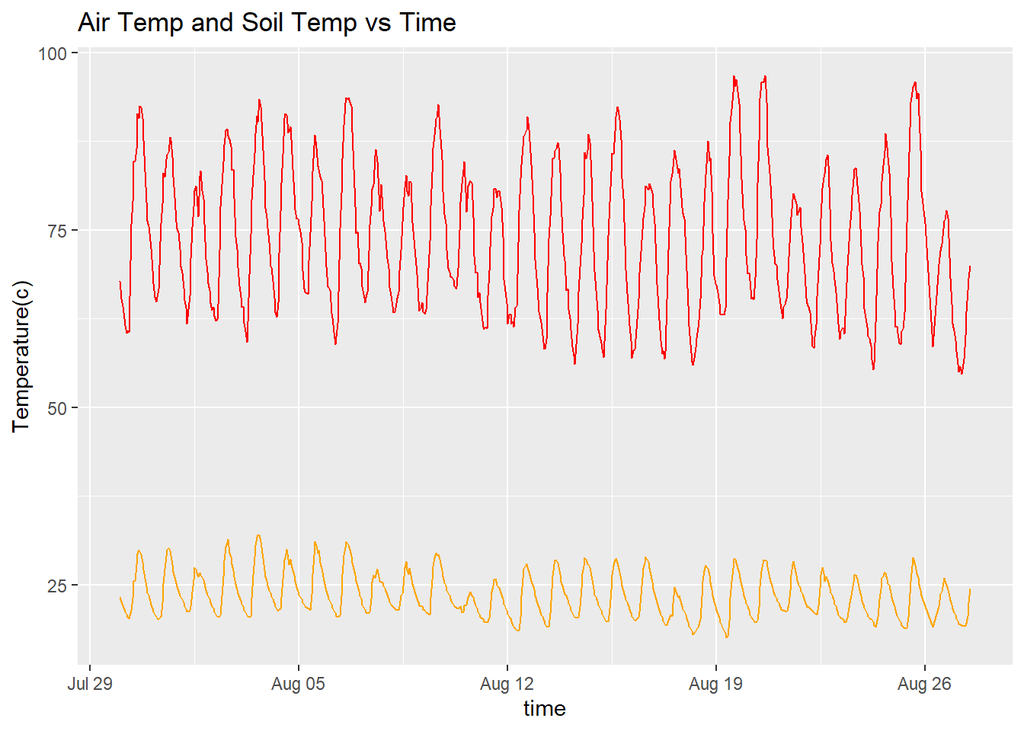

```r
plot3 = ggplot() +
geom_line(data = finalDataSet_long, aes(x = time, y = temperature), color = "red") +
  geom_line(data = finalDataSet_long, aes(x = time, y = soilTempC), color = "orange")+
  ylab("Temperature(c)")+
  ggtitle("Air Temp and Soil Temp vs Time")

plot3
```

# Future Steps Recap and Questions

- Run stats analysis on the difference between sensors and the control(EC5’s)
- Create and install more systems on golf courses and residential turf
- Look into AI and machine learning packages
- IRT sensors added to dataset
- Look for use-cases and ultimatly wyas to automate irrigation